# s670-HW3

Ruchik Rohit Dama

9/22/2021

#### Extracting the data from NHANES and omitting all NA values from the data.

```r
nhanes.data=subset(NHANES, select = c("BPSysAve","Age","Weight","Height","Gender"))
nhanes.data=na.omit(nhanes.data)
nhanes.data
```

```
## # A tibble: 8,487 x 5
##    BPSysAve   Age Weight Height Gender
##       <int> <int>  <dbl>  <dbl> <fct>
##  1      113    34   87.4   165. male
##  2      113    34   87.4   165. male
##  3      113    34   87.4   165. male
##  4      112    49   86.7   168. female
##  5       86     9   29.8   133. male
##  6      107     8   35.2   131. male
##  7      118    45   75.7   167. female
##  8      118    45   75.7   167. female
##  9      118    45   75.7   167. female
## 10      111    66   68     170. male
## # ... with 8,477 more rows
```

```r
nhanes.male=filter(nhanes.data, Gender == 'male')
nhanes.female=filter(nhanes.data, Gender == 'female')
```

#### Plotting Age v/s Average Systolic Blood Pressure

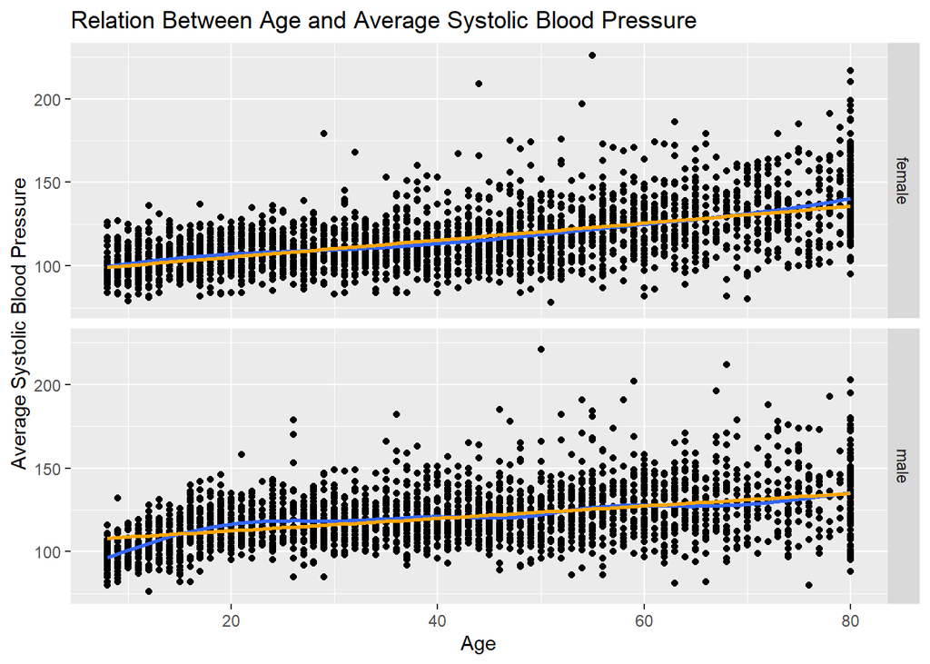

```r
lines = c("lm" = "orange", "gam" = "blue")
ggplot(nhanes.data,aes(x = Age , y = BPSysAve))+geom_point()+labs(title = "Relation Between Age and Average Systolic Blood Pressure",x="Age",y="Average Systolic Blood Pressure")+ stat_smooth(method='gam', se = FALSE)+ stat_smooth(method='lm', se = FALSE,color='orange')+facet_grid(Gender~.)
```

```r
print("Slope of Age v/s Avg Systolic Blood Pressure for Female")
```

```
## [1] "Slope of Age v/s Avg Systolic Blood Pressure for Female"
```

```r
coef(lm(BPSysAve~Age,data=nhanes.female))[2]
```

```
##       Age
## 0.5065429
```

```r
print("Slope of Age v/s Avg Systolic Blood Pressure for male")
```

```
## [1] "Slope of Age v/s Avg Systolic Blood Pressure for male"
```

```r
coef(lm(BPSysAve~Age,data=nhanes.male))[2]
```

```
##       Age
## 0.3718979
```

In the graph, the orange line represents lm whereas blue line represents gam. From the above graph, we can see the systolic blood pressure is increasing as the Age increases. We can see that the systolic blood pressure of female has more increase in slope than the male.I am using both linear modeling and generalized acyclic modeling. We can see the regression lines are nearly overlapping each other, So there is not much of difference between lm and gam.So, I chose lm, to not increase the complexity of the model. I am using lm to calculate the slope of the graphs.

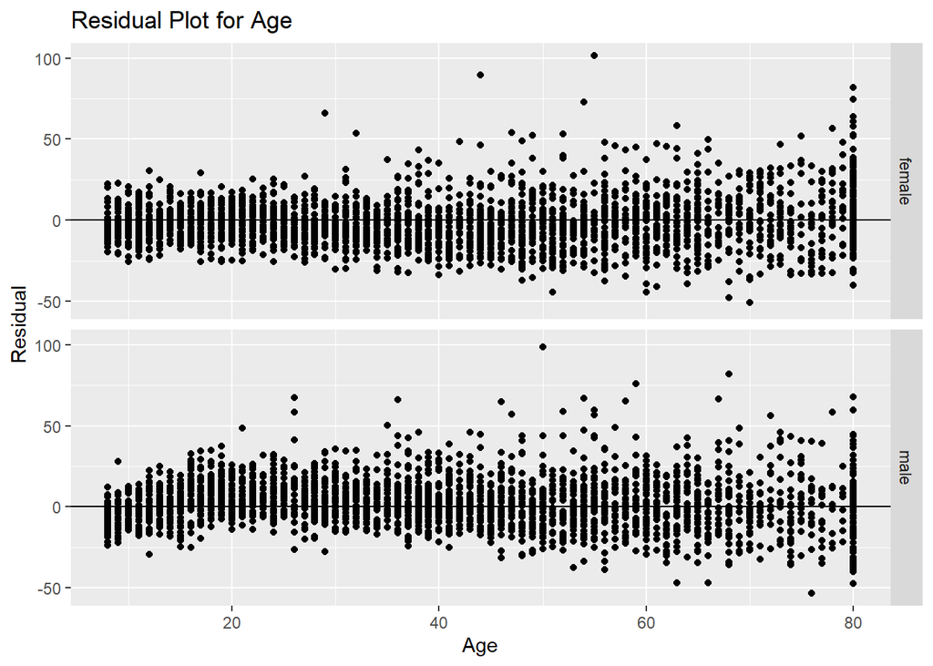

```r
nhanes.data.lm=lm(BPSysAve~Age,data=nhanes.data)
nhanes.data$age_residual=augment(nhanes.data.lm)$.resid
ggplot(nhanes.data,aes(x = Age, y = age_residual))+geom_point()+labs(title = "Residual Plot for Age",x="Age",y="Residual")+facet_grid(Gender~.)+geom_abline(slope=0)
```

#### Plotting Height v/s Average Systolic Blood Pressure

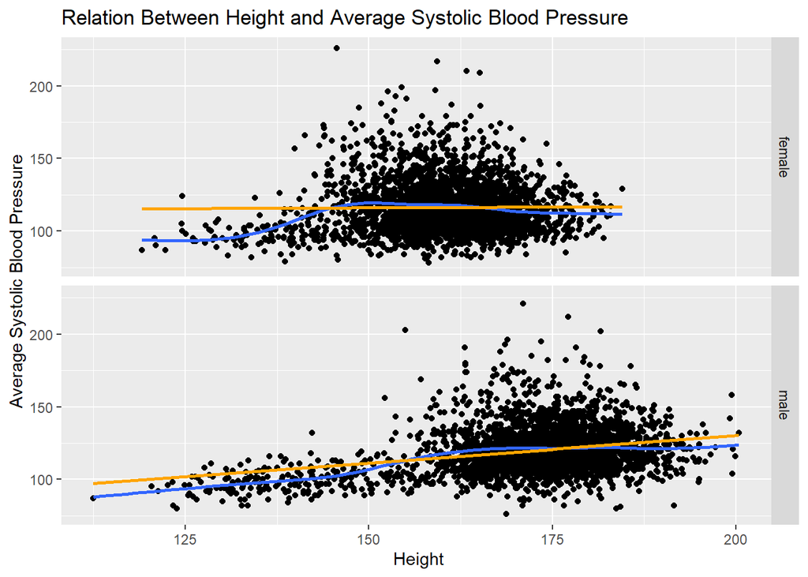

```r
ggplot(nhanes.data,aes(x = Height , y = BPSysAve))+geom_point()+labs(title = "Relation Between Height and Average Systolic Blood Pressure",x=" Height",y="Average Systolic Blood Pressure")+ stat_smooth(method='gam', se = FALSE) + stat_smooth(method='lm', se = FALSE,color='orange')+facet_grid(Gender~.)
```

```r
print("Slope of Height v/s Avg Systolic Blood Pressure for female")
```

```
## [1] "Slope of Height v/s Avg Systolic Blood Pressure for female"
```

```r
coef(gam(BPSysAve~Height,data=nhanes.female))[2]
```

```
##     Height
## 0.02129982
```

```r
print("Slope of height v/s Avg Systolic Blood Pressure for male")
```

```
## [1] "Slope of height v/s Avg Systolic Blood Pressure for male"
```

```r
coef(gam(BPSysAve~Height,data=nhanes.male))[2]
```

```
##    Height
## 0.3773058
```

In the graph, the orange line represents lm whereas blue line represents gam. From the above graphs, we can see that gam fits the data much better than lm. We can see that the gam’s regression line increases till the height reaches between 150-160 and then it stays constant. We can see that that is there is increasing positive trend for male and no visible trend for female.So, we can say that height is a better indicator for male’s Systolic blood pressure than female’s systolic blood pressure.

```r
nhanes.data.gam=gam(BPSysAve~Height,data=nhanes.data)
nhanes.data$height_residual=augment(nhanes.data.gam)$.resid
```

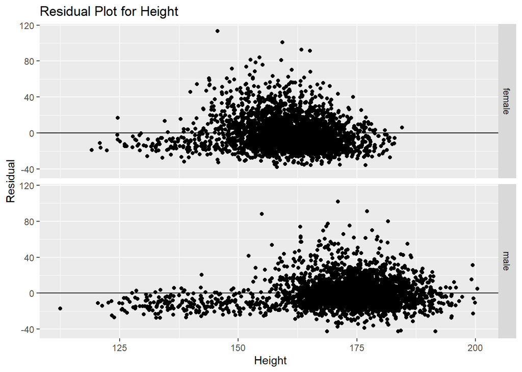

```r
ggplot(nhanes.data,aes(x = Height, y = height_residual))+geom_point()+labs(title = "Residual Plot for Height",x=" Height",y="Residual")+facet_grid(Gender~.)+geom_abline(slope=0)
```

#### Plotting Weight v/s Average Systolic Blood Pressure

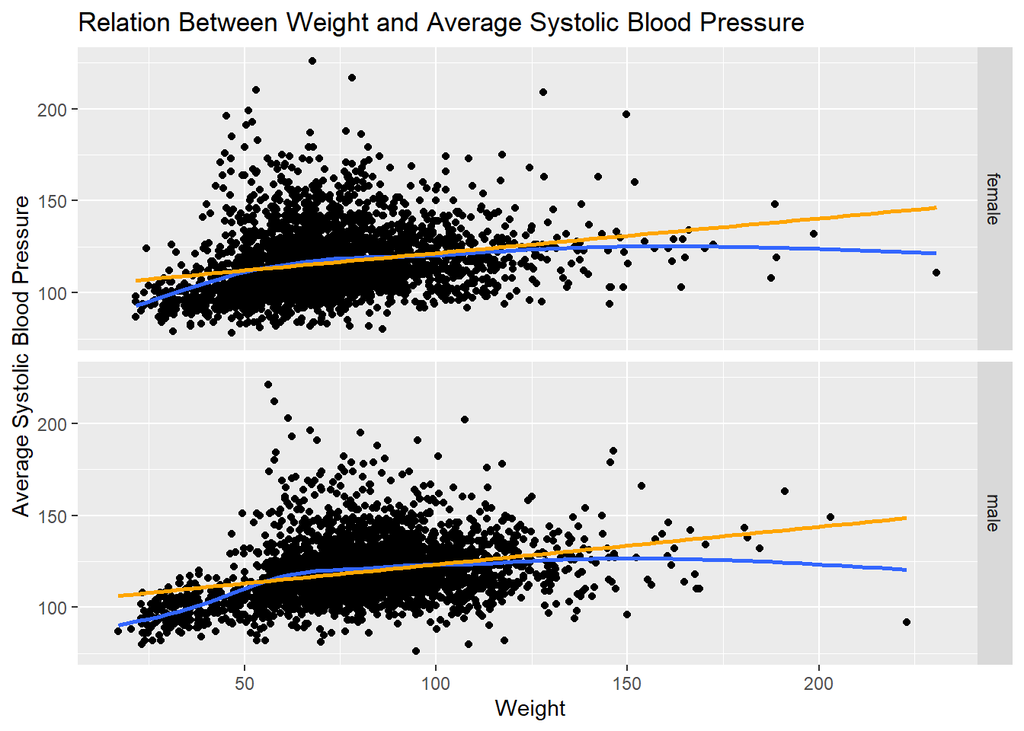

```r
ggplot(nhanes.data,aes(x = Weight , y = BPSysAve))+geom_point()+labs(title = "Relation Between Weight and Average Systolic Blood Pressure",x=" Weight",y="Average Systolic Blood Pressure")+ stat_smooth(method='gam', se = FALSE)+ stat_smooth(method='lm', se = FALSE,color='orange')+facet_grid(Gender~.)
```

```r
print("Slope of Weight v/s Avg Systolic Blood Pressure for female")
```

```
## [1] "Slope of Weight v/s Avg Systolic Blood Pressure for female"
```

```r
coef(lm(BPSysAve~Weight,data=nhanes.female))
```

```
## (Intercept)      Weight
## 102.7005589   0.1888152
```

```r
print("Slope of Weight v/s Avg Systolic Blood Pressure for male")
```

```
## [1] "Slope of Weight v/s Avg Systolic Blood Pressure for male"
```

```r
coef(lm(BPSysAve~Weight,data=nhanes.male))
```

```
## (Intercept)      Weight
## 102.8121814   0.2050706
```

In the graph, the orange line represents lm whereas blue line represents gam. From the above graphs, we can see that gam fits the data much better than lm. We can see that the gam’s regression line increases till the weight reaches between 60-80 and then it stays constant. There isn’t much of a difference between the slopes of male’s graph and female’s graph.

```r
nhanes.data.gam=gam(BPSysAve~Weight,data=nhanes.data)
nhanes.data$weight_residual=augment(nhanes.data.gam)$.resid
```

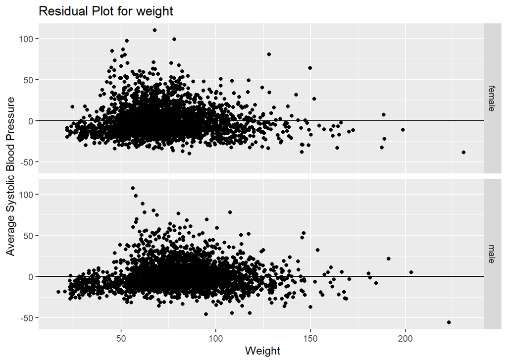

```r
ggplot(nhanes.data,aes(x = Weight, y = weight_residual))+geom_point()+labs(title = "Residual Plot for weight",x=" Weight",y="Average Systolic Blood Pressure")+facet_grid(Gender~.)+geom_abline(slope=0)
```